# Homework 1

Alper Koray YILDIZ, 20080508

**Question 1** With Markdown write a sentence that has one word in bold.

**Valorant** is my favourite pc game.

**Question 2** With Markdown write a sentence that has one word in italic.

I like coding *R*.

**Question 3** With Markdown write a sentence that has one word in italic bold.

I am from *Ankara*.

**Question 4** With Markdown write an unordered list with three items.

My shopping list

- Egg
- Bread
- Milk

**Question 5** With Markdown write an ordered list with three items.

Our lessons in today

1. Contemporary Global Issues
2. Macroeconomics
3. Introduction to Data Science

**Question 6** With Markdown give a link to your favorite webpage.

My best webpage in my university career is [here!](https://ekampus.ankara.edu.tr/)

**Question 7** With Markdown add a cat picture.

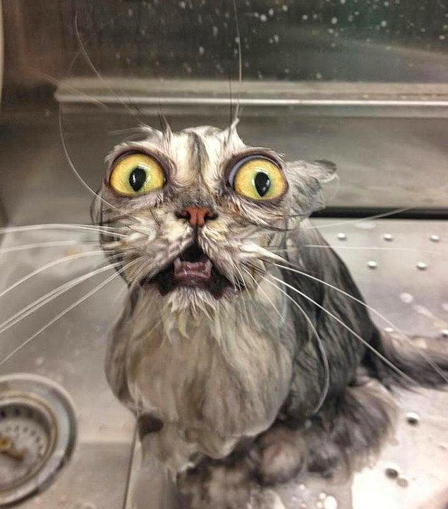

Haydar

**Question 8** With Rmarkdown insert a code chunk and give an example of a simple mathematical calculation in it.

```r
5*2
```

```
## [1] 10
```

**Question 9** With $LaTeX$ write your favorite equation in block form.

$E=m*c^{2}$

**Question 10** In a code chunk calculate 3 + 4.

```r
3+4
```

```
## [1] 7
```